# Epigenomic Analysis in Monocytes: Histones marks and Transcriptional factors

Paola Albarrán Godoy, Ariadna Badia Zamudio, Yael Daniel Hernandez Gonzalez

2025-05-06

# Introduction

The article *“Lineage-Specific Genome Architecture Links Enhancers and Non-coding Disease Variants to Target Gene Promoters”* investigates how lineage-specific genome architecture contributes to connecting enhancers and non-coding disease variants with their target gene promoters. To better understand how specific genomic features—such as chromatin loops and topologically associating domains (TADs)—mediate these interactions in a cell type-specific manner, the authors integrate computational and experimental approaches. Their findings highlight the role of genome architecture in shaping regulatory landscapes that underlie tissue- and cell-type-specific gene expression and disease susceptibility.

H3K27ac is a histone modification associated with active enhancers and promoters, marking regions of open chromatin and transcriptional activity. It plays a crucial role in gene regulation and is context-dependent, dynamic, and functionally linked to cell identity and disease. In this study, we analyzed the enrichment of H3K27ac in promoters and PIRs (promoter-interacting regions) of **CD14⁺ monocytes** using ENCODE ChIP-Seq data. Our aim was to better understand the epigenetic mechanisms underlying gene regulation in monocytes, focusing on how H3K27ac contributes to establishing and maintaining cell type-specific transcriptional programs. Since transcription factors often function in a cell type-specific manner, we further explored which TF motifs are enriched in monocyte promoters and PIRs using pattern matching approaches. This allowed us to infer potential regulators that may cooperate with H3K27ac to drive monocyte-specific gene expression.

# Pipeline (With Code)

## File preprocessing

We download from the [page](https://osf.io/u8tzp/files/osfstorage) the interaction file `PCHiC_peak_matrix_cutoff5.txt.gz` .

And then upload the file to the cluster with:

```
scp /home/yael/Descargas/PCHiC_peak_matrix_cutoff5.txt.gz yhernandezg@dna.lavis.unam.mx:/mnt/atgc-d1/bioinfoII/yhernandezg/epigenomica/data
```

After, the link [epigenomesportal](https://epigenomesportal.ca/ihec/grid.html?build=2020-10&assembly=4&institutions=4&cellTypeCategories=1) the histone mark H3K27ac of the CD14-positive monocyte cell type was chosen.

We opened the link [encode project](https://www.encodeproject.org/experiments/ENCSR000ASJ/) , and selected the reference genome hg19, the filters in bigwig files > fold change over control > replicates 1,2, and we obtained that the file would be [ENCFF931PZJ](https://www.encodeproject.org/files/ENCFF931PZJ/).

**Generate bigwig from fastq**

To generate the bigWig files from the FASTQ files in the ChIP-seq experiment (ENCSR000ASJ), the process followed by the ENCODE pipeline is summarized in the following steps:

1. Initial Processing (ChIP-seq Mapping Pipeline)
   - Input: FASTQ files (can be paired reads, single stranded or non strand specific).
   - Concatenation: If there are multiple FASTQ files from the same biological replicate (e.g. separate sequencing runs), they are concatenated before mapping,
   - Mapping:Reads are aligned to the reference genome (hg19) using tools not specified in the papers (but commonly BWA, Bowtie2, or MAQ are used)
   - Filtering: Reads with multiple alignments are removed.
   - Output: BAM files with filtered alignments.
2. Signal generation (ChIP-seq Pipeline Overview)
   - Input: BAM files of replicates and controls.
   - Fragment density calculation:
     - IGVtools count is used with the parameters:
       - -w 25: 25 bp window to calculate density.
       - -f mean: Reports the average signal value in the window.
       - -e 200: Extends reads to 200 bp (typical for ChIP-seq).
       - Intermediate output: File in WIG format.
   - Conversion to bigWig: WigToBigWig (from the UCSC Kent package) is used to convert the WIG to bigWig, an efficient binary format.
3. Standardization and final signal
   - The bigWig signal is normalized by control (Input) to generate fold-over-control plots or p-values .
   - This is done for each replicate and for pooled replicates.

A job prepare_monocyte_data.sh, for processing, is commanded to prepare epigenomic data related to promoter-PIR interactions in monocytes, downloading files, filtering relevant interactions and generating clean BED files.

```
cd /mnt/atgc-d1/bioinfoII/yhernandezg/epigenomica/data

#Download the H3K27ac BigWig file directly from ENCODE.

wget -O ENCFF931PZJ.bigWig "https://www.encodeproject.org/files/ENCFF931PZJ/@@download/ENCFF931PZJ.bigWig"
```

-O ENCFF931PZJ.bigWig indicates the name under which the file will be saved.

```
zcat PCHiC_peak_matrix_cutoff5.txt.gz | awk -F'\t' 'NR==1 || $12 > 0' > monocyte_interactions.tsv
```

- zcat: decompress the .gz file.
- awk -F’\t’: uses tabulator as field separator.
- NR==1 || $12 > 0: keep header (NR==1) and rows where column 12 (score) is greater than 0.
- Save the result in monocyte_interactions.tsv.

```
awk -F'\t' '
NR>1 && ($1 ~ /^[0-9XY]+$/) && ($1 != "Y" || $3 <= 57227415) {
  print "chr"$1"\t"$2"\t"$3"\t"$4
}' monocyte_interactions.tsv \
| awk '$1 ~ /^chr([1-9]|1[0-9]|2[0-2]|X|Y|M)$/' \
| sort -k1,1 -k2,2n | uniq > Monocyte_Promoters_mainChr.bed

awk -F'\t' '
NR>1 && ($6 ~ /^[0-9XY]+$/) && ($6 != "Y" || $8 <= 57227415) {
  print "chr"$6"\t"$7"\t"$8"\t"$9
}' monocyte_interactions.tsv \
| awk '$1 ~ /^chr([1-9]|1[0-9]|2[0-2]|X|Y|M)$/' \
| sort -k1,1 -k2,2n | uniq > Monocyte_PIRs_mainChr.bed
```

- First awk: takes rows with numerical chromosomes, X or Y, and discards regions outside the known Y chromosome boundary (avoids errors due to incorrect annotations).
- Adds the prefix “chr” to chromosome names.
- Second awk: filters only standard human chromosomes (1-22, X, Y, M).
- sort: sort by chromosome and starting position.
- uniq: remove duplicates.
- Result: clean BED file with promoter regions.

## Histone Marks Enrichment

### Signal in Promoters and PIRs

Then to obtain the histone signal in chromosomal regions given in the .bed files, generated from the interactions file, the job was sent Histone_Signal.sh which performs BED file filtering according to the actual chromosome size (obtained from the BigWig file) and then calculates the H3K27ac signal.

```
INPUT_DIR="/mnt/atgc-d1/bioinfoII/yhernandezg/epigenomica/data"
OUTPUT_DIR="/mnt/atgc-d1/bioinfoII/yhernandezg/epigenomica/results"

module load UCSC-executables/12may2022
```

Variables are defined for input and output routes. and load UCSC tools subset.

```
bigWigInfo "${INPUT_DIR}/ENCFF931PZJ.bigWig" -chroms | awk '{print $1"\t"$3}' > "${INPUT_DIR}/chrom_sizes.txt"
```

- bigWigInfo file.bigWig -chroms: lists the chromosomes in the BigWig file with their size.
- The output contains three columns: chromosome name, number of bases and total size.
- awk ‘{print $1”\t”$3}’: extracts only the chromosome name ($1) and its length ($3).
- Result: chrom_sizes.txt file with two columns: chrN <length>.

```
awk '
  BEGIN { FS=OFS="\t" }
  FNR==NR { chr_len[$1]=$2; next }
  $1 in chr_len && $3 <= chr_len[$1]
' "${INPUT_DIR}/chrom_sizes.txt" "${INPUT_DIR}/Monocyte_Promoters_mainChr.bed" > "${INPUT_DIR}/Monocyte_Promoters_final.bed"

awk '
  BEGIN { FS=OFS="\t" }
  FNR==NR { chr_len[$1]=$2; next }
  $1 in chr_len && $3 <= chr_len[$1]
' "${INPUT_DIR}/chrom_sizes.txt" "${INPUT_DIR}/Monocyte_PIRs_mainChr.bed" > "${INPUT_DIR}/Monocyte_PIRs_final.bed"
```

- This awk compares two files:
  - First, it reads chrom_sizes.txt and stores the maximum sizes per chromosome in chr_len.
  - Then, it processes Monocyte_Promoters_mainChr.bed and discards any lines where the final coordinate $3 exceeds the chromosome length.
- This is crucial to avoid errors when tools like bigWigAverageOverBed try to access out-of-range positions.

```
bigWigAverageOverBed \
"${INPUT_DIR}/ENCFF931PZJ.bigWig" \
"${INPUT_DIR}/Monocyte_Promoters_final.bed" \
"${OUTPUT_DIR}/promoters_signal.tab"

bigWigAverageOverBed \
"${INPUT_DIR}/ENCFF931PZJ.bigWig" \
"${INPUT_DIR}/Monocyte_PIRs_final.bed" \
"${OUTPUT_DIR}/PIRs_signal.tab"
```

bigWigAverageOverBed: calculates the signal average of a BigWig file over the regions specified in a BED file.

- The output includes columns such as:
  - region name,
  - size,
  - number of bases covered,
  - sum of values,
  - signal average.

Then, we upload the output files `PIRs_signal.tab` and `promoters_signal.tab` to our local repository.

### Heatmaps display

We generate signal heatmaps from bed and bigwig files, through the job heatmaps.sh . Calculate matrices of epigenomic signal coverage values (in this case, H3K27ac) around regions of interest (promoters and PIRs).

```
BW="/mnt/atgc-d1/bioinfoII/yhernandezg/epigenomica/data/ENCFF931PZJ.bigWig"
PROMOTERS="/mnt/atgc-d1/bioinfoII/yhernandezg/epigenomica/data/Monocyte_Promoters_final.bed"
PIRS="/mnt/atgc-d1/bioinfoII/yhernandezg/epigenomica/data/Monocyte_PIRs_final.bed"
OUT="/mnt/atgc-d1/bioinfoII/yhernandezg/epigenomica/results"

### Promoters
computeMatrix reference-point \
    -S $BW \
    -R $PROMOTERS \
    --referencePoint center \
    -a 2000 -b 2000 \
    --binSize 50 \
    --missingDataAsZero \
    -out $OUT/matrix_H3K27ac_promoters.tab.gz

### PIRs
computeMatrix reference-point \
    -S $BW \
    -R $PIRS \
    --referencePoint center \
    -a 2000 -b 2000 \
    --binSize 50 \
    --missingDataAsZero \
    -out $OUT/matrix_H3K27ac_PIRs.tab.gz
```

Where:

- reference-point:
  - Calculation mode where regions of interest are aligned by a reference point (e.g. center, TSS, TES).
- -S $BW (--scoreFileName):
  - bigWig file containing the epigenomic signal (H3K27ac) to be analyzed.
- -R $PROMOTERS or $PIRS (--regionsFileName):
  - BEDs file with the genomic coordinates of the promoters and PIRs.
- --referencePoint center:
  - Reference point to align the regions. In this case, the center of each BED region.
  - Common alternatives: TSS (start of transcription) or TES (end of transcription).
- -a 2000 -b 2000 (--beforeRegionStartLength / --afterRegionStartLength):
  - Defines a window of 2000 bp upstream (-a) and 2000 bp downstream (-b) of the reference point.
  - That is, a 4 kb region centered on the promoter is analyzed.
- --binSize 50:
  - Divides each region into bins (intervals) of 50 bp and calculates the average signal in each bin.
  - This reduces noise and simplifies visualization.
- --missingDataAsZero:
  - Treats regions with no data in the bigWig as zeros (avoids errors due to missing values).
- -out :
  - Saves the compressed matrix in .tab.gz format.

```
### Promoters
plotHeatmap \
    -m $OUT/matrix_H3K27ac_promoters.tab.gz \
    -out $OUT/heatmap_H3K27ac_promoters.png \
    --refPointLabel "center" \
    --heatmapHeight 10 \
    --regionsLabel "Promoters" \
    --plotTitle "A. H3K27ac signal at Promoters" \
    --colorMap "RdBu" \

### PIRs
plotHeatmap \
    -m $OUT/matrix_H3K27ac_PIRs.tab.gz \
    -out $OUT/heatmap_H3K27ac_PIRs.png \
    --refPointLabel "center" \
    --heatmapHeight 10 \
    --regionsLabel "PIRs" \
    --plotTitle "B. H3K27ac signal at PIRs" \
    --colorMap "RdBu"
```

Where:

- -m (--matrixFile)
  - Specifies the input matrix generated by computeMatrix
- -out
  - Defines the output file
  - Supported format: .png, .pdf, .svg, etc.
- --refPointLabel “center”
  - Label of the reference point (in this case, the center of the regions).
  - It will appear on the X axis of the heatmap.
- --heatmapHeight 10
  - Height of the heatmap in cm (useful to adjust the visual aspect).
- --regionsLabel “Promoters” or “PIRs”
  - Label for the regions (appears in the legend).
- --plotTitle
  - Graph title.
- --colorMap “RdBu”
  - Color palette (in this case, divergent Red-Blue).

Also, we generated z-scored signal heatmaps, to compare better the spacial patterns, regardless of the magnitude. We send this job heatmaps_zcore.sh

We use the same matrix that the other heatmaps. And only add the option --zMin -3 --zMax 3 to normalizate both of the matrix in the heatmaps.

## Transcriptional Factors Enrichment in motifs

We now move on to identify TF binding sites by means of matrix-based pattern matching. We will search for motifs within sequences and their hits with transcriptional factors.

### Extract sequences

First we extract the sequence from the coordinates of the .bed files and the reference genome (hg19.fa). By means of the following job extract_sequences.sh

```
module load bedtools/2.27.1

INPUT_DIR="/mnt/atgc-d1/bioinfoII/yhernandezg/epigenomica/data"

bedtools getfasta -fi "$INPUT_DIR/hg19.fa" -bed "$INPUT_DIR/Monocyte_Promoters_final.bed" -fo "$INPUT_DIR/promoters.fa"
bedtools getfasta -fi "$INPUT_DIR/hg19.fa" -bed "$INPUT_DIR/Monocyte_PIRs_final.bed" -fo "$INPUT_DIR/PIRs.fa"
```

Where:

- -fi: Specifies the input FASTA file (in this case, the reference genome hg19).
- -bed: Indicates the BED file containing the genomic coordinates of the regions to be extracted.
- -fo: Especifica el archivo FASTA de salida donde se guardarán las secuencias extraídas.

### Shuffled sequences

We then generated permuted sequences for both .fasta files, as these will be our controls under randomization and can later compare statistically whether the motif with the transcription factor is significantly relevant. First we generated the script in R for the permuted sequences [sequences_shuffle](https://github.com/YaelHernG/Epigenomics/blob/main/Scripts/sequences_shuffle.R)

```
suppressPackageStartupMessages({
  library(Biostrings)
})

# ------------ 1. Entrada de argumentos----------------
args <- commandArgs(trailingOnly = TRUE)

if (length(args) < 3) {
  cat("Uso: Rscript shuffle_fasta.R <input.fa> <output.fa> <kmer_size>\n")
  quit(status = 1)
}

input_file <- args[1]       # FASTA de entrada
output_file <- args[2]      # FASTA de salida
kmer_size <- as.integer(args[3])  # tamaño de k-mer a conservar
```

The script receives three parameters from the command line:

- <input.fa>: input FASTA file with DNA sequences.
- <output.fa>: Output FASTA file with permuted sequences.
- <kmer_size>: Size of the k-mers to be retained during permutation.

If the required arguments are not provided, the script displays a help message and terminates

```
set.seed(42) # reproducibilidad

# ------------ 2. Función de permutación---------------
shuffle_sequence <- function(seq, k) {
  seq <- toupper(as.character(seq))
  nucs <- strsplit(seq, "")[[1]]

  if (k <= 1) {
    return(paste(sample(nucs), collapse = ""))
  } else {
    kmers <- substring(seq, seq(1, nchar(seq) - k + 1, by = k), seq(k, nchar(seq), by = k))
    shuffled_kmers <- sample(kmers)
    return(paste(shuffled_kmers, collapse = ""))
  }
}
```

This function takes a DNA sequence and permutes it in two ways, depending on the value of k:

- If k <= 1:
  - It decomposes the sequence into individual nucleotides.
  - It mixes them randomly (sample(nucs)).
- If k > 1:
  - Splits the sequence into k-mers (subsequences of length *k*).
  - Mixes the order of the k-mers, but preserves their internal composition

```
# ------------ 3. Leer FASTA---------------------------
cat("Leyendo archivo:", input_file, "...\n")
sequences <- readDNAStringSet(input_file)

# ------------ 4. Aplicar permutación------------------
cat("Generando permutaciones...\n")
shuffled_seqs <- DNAStringSet(
  sapply(as.character(sequences), shuffle_sequence, k = kmer_size)
)
names(shuffled_seqs) <- names(sequences)
```

Use the readDNAStringSet function of the Biostrings package to load the sequences into memory.

Applies the shuffle_sequence function to each FASTA sequence.

Retain the names of the original sequences in the result.

```
# ------------ 5. Guardar resultado-------------------
cat("Guardando resultado en:", output_file, "\n")
writeXStringSet(shuffled_seqs, output_file)

# ------------ 6. Reporte básico-----------------------
cat("\n=== Reporte de Calidad ===\n")
cat("Total de secuencias:", length(sequences), "\n")
cat("Longitud promedio original:", round(mean(width(sequences))), "bp\n")
cat("Longitud promedio permutada:", round(mean(width(shuffled_seqs))), "bp\n")
```

Write the permuted sequences to a new FASTA file using writeXStringSet.

Then we sent a job generate_sequences.sh to run the R script for each fasta.

```
DATA_DIR="/mnt/atgc-d1/bioinfoII/yhernandezg/epigenomica/data"
SCRIPT="/mnt/atgc-d1/bioinfoII/yhernandezg/epigenomica/scripts/sequences_shuffle.R"

# Ejecutar para promoters
echo "Permutando promoters.fa..."
Rscript "$SCRIPT" "$DATA_DIR/promoters.fa" "$DATA_DIR/promoters_shuffled.fa" 2

# Ejecutar para PIRs
echo "Permutando PIRs.fa..."
Rscript "$SCRIPT" "$DATA_DIR/PIRs.fa" "$DATA_DIR/PIRs_shuffled.fa" 2
```

We also downloaded the non-redundant JASPAR collection for RSAT in transfac format. Using the job Download_jaspar_rsat.sh

### Backgrounds models

We generate background models for developers and PIRs. These models provide a statistical baseline to assess whether the observed frequency of a motif is significant or random. They were generated using the following jobs Create_BM_Promoters.sh and Create_BM_PIRs.sh

```
module load rsat/8sep2021

# --- Directorios ---
DATA_DIR="/mnt/atgc-d1/bioinfoII/yhernandezg/epigenomica/data"

#----Concatenar archivos---
cat "$DATA_DIR/promoters.fa" "$DATA_DIR/promoters_shuffled.fa" > "$DATA_DIR/promoters_combined.fa"

cat "$DATA_DIR/PIRs.fa" "$DATA_DIR/PIRs_shuffled.fa" > "$DATA_DIR/PIRs_combined.fa"

#----Generar el background model---
create-background-model \
  -i "$DATA_DIR/promoters_combined.fa" \
  -markov 1 \
  -out_format oligo-analysis \
  -o "$DATA_DIR/promoters_bm.bg"

create-background-model \
  -i "$DATA_DIR/PIRs_combined.fa" \
  -markov 1 \
  -out_format oligo-analysis \
  -o "$DATA_DIR/PIRs_bm.bg"
```

Where:

- -i :Input FASTA file containing the original + permuted sequences.
- -markov 1: Specifies the order of the Markov model (in this case, 1 = first order model).
- -out_format oligo-analysis: Output format compatible with RSAT tools such as oligo-analysis and matrix-scan.
- -o: Output file where the background model will be saved.

Permuted and real rates were concatenated to balance the model, avoid overfitting and improve generalization.

### Matrix-scan

Next, we ran a matrix-scan that identifies transcription factor binding motifs in DNA sequences. It compares the sequences against a matrix of known motif weights (JASPAR) and predicts significant binding sites.

For this part of the analysis, matrix-scan was run for permuted promoters as follows with this job RSAT_Promoters_Shuffled.sh

```
# --- Directorios ---
DATA_DIR="/mnt/atgc-d1/bioinfoII/yhernandezg/epigenomica/data"
MOTIFS_DIR="/mnt/atgc-d1/bioinfoII/yhernandezg/epigenomica/motifs"
RESULTS_DIR="/mnt/atgc-d1/bioinfoII/yhernandezg/epigenomica/results"

# Ejecutar matrix-scan-quick
matrix-scan \
  -quick \
  -i "$DATA_DIR/promoters_shuffled.fa" \
  -m "$MOTIFS_DIR/JASPAR2022_CORE_non-redundant_pfms_transfac.txt" \
  -matrix_format transfac \
  -seq_format fasta \
  -origin start \
  -lth score 0.8 \
  -bgfile "$DATA_DIR/promoters_bm.bg" \
  -2str \
  -o "$RESULTS_DIR/matrixscan_promoters_shuffled.tsv"
```

Where:

- -quick : Fast mode (optimized for speed, less accuracy possible).
- -i : FASTA file with sequences
- -m File with motif matrices in TRANSFAC format (from JASPAR 2022).
- -matrix_format: Indicates that the matrices are in TRANSFAC format.
- -seq_format: Format of the input sequences (FASTA).
- -origin: Consider the start position of the sequence as a reference for the coordinates.
- -lth score : Minimum score threshold for reporting a reason (range: 0 to 1).
- -bgfile: Background model to normalize scores.
- -2str: Scans both strands (sense and antisense) of DNA.
- -o: Output file in TSV format (tab-separated values).

Due to the long execution time that matrix-scan takes to run through all sequences and motifs. For real promoters and both real and permuted PIRs, each of the fastas was divided into 24 individual files (due to the number of chromosomes) for each fasta file.

The job sent to split the fasta files was as follows Split_fasta_by_chr_pirs.sh

```
DATA_DIR="/mnt/atgc-d1/bioinfoII/yhernandezg/epigenomica/data"
REAL_OUT="$DATA_DIR/pirs_real_fasta_chr"
SHUFFLED_OUT="$DATA_DIR/pirs_shuffled_fast_chr"

CHROMOSOMES=$(seq 1 22)
CHROMOSOMES+=" X Y"

# Dividir PIRs.fa (real)
for CHR in $CHROMOSOMES; do
    awk -v chr="$CHR" 'BEGIN{RS=">"; FS="\n"} $1 ~ ("chr" chr) {print ">" $0}' "${DATA_DIR}/PIRs.fa" > "${REAL_OUT}/chr${CHR}.fa"
done

# Dividir PIRs_shuffled.fa (shuffled)
for CHR in $CHROMOSOMES; do
    awk -v chr="$CHR" 'BEGIN{RS=">"; FS="\n"} $1 ~ ("chr" chr) {print ">" $0}' "${DATA_DIR}/PIRs_shuffled.fa" > "${SHUFFLED_OUT}/chr${CHR}.fa"
done

REAL_OUT="$DATA_DIR/promoters_real_fast_chr"

# Dividir promoters.fa (real)
for CHR in $CHROMOSOMES; do
    awk -v chr="$CHR" 'BEGIN{RS=">"; FS="\n"} $1 ~ ("chr" chr) {print ">" $0}' "${DATA_DIR}/promoters.fa" > "${REAL_OUT}/chr${CHR}.fa"
done
```

Where:

- -v chr=“$CHR”: Pass the current chromosome number (CHR) as a chr variable to awk.
- BEGIN{RS=“>”; FS=“}:
  - RS=“>”: Defines the record separator as > (each FASTA sequence starts with >).
  - FS=“\n”: Uses line breaks as field separator to process headers and sequences separately.
- $1 ~ (“chr” chr): Filters sequences whose header ($1) matches the pattern “chr” followed by the chromosome number (e.g. chr1, chrX).
- {print “>” $0}: Rebuilds the FASTA format (adds > to the beginning of each record).
- Save the sequences in files such as ${REAL_OUT}/chr${CHR}.fa

Real promoters fasta file was split in other job Split_fasta_by_chr_promoters.sh with the same configuration and options than PIRs.

Then, for each individual phage per chromosome, DNA binding motif scanning was applied by matrix-scan in parallel.

The following job Submit_matrixscan_jobs_pirs.sh creates a job array with 48 tasks (24 chromosomes x 2 conditions) and another job with 24 tasks for real promoters Submit_matrixscan_jobs_promoters.sh.

```
# ===== Configuración de rutas =====
DATA_DIR="/mnt/atgc-d1/bioinfoII/yhernandezg/epigenomica/data"
REAL_FASTA_DIR="${DATA_DIR}/pirs_real_fasta_chr"
SHUFFLED_FASTA_DIR="${DATA_DIR}/pirs_shuffled_fast_chr"
MOTIFS_FILE="/mnt/atgc-d1/bioinfoII/yhernandezg/epigenomica/motifs/JASPAR2022_CORE_non-redundant_pfms_transfac.txt"
BG_FILE="${DATA_DIR}/PIRs_bm.bg"
RESULTS_DIR="/mnt/atgc-d1/bioinfoII/yhernandezg/epigenomica/results/matrixscan_chr"

# ===== Determinar tipo (real/shuffled)  y cromosoma =====
CHROMOSOMES=( $(seq 1 22) X Y )

if [ $SGE_TASK_ID -le 24 ]; then
    TYPE="real"
    CHR_IDX=$((SGE_TASK_ID - 1))
    CHROMOSOME=${CHROMOSOMES[$CHR_IDX]}
    INPUT_FASTA="${REAL_FASTA_DIR}/chr${CHROMOSOME}.fa"
    OUTPUT_TSV="${RESULTS_DIR}/pirs_real/chr${CHROMOSOME}.tsv"
else
    TYPE="shuffled"
    CHR_IDX=$((SGE_TASK_ID - 25))
    CHROMOSOME=${CHROMOSOMES[$CHR_IDX]}
    INPUT_FASTA="${SHUFFLED_FASTA_DIR}/chr${CHROMOSOME}.fa"
    OUTPUT_TSV="${RESULTS_DIR}/pirs_shuffled/chr${CHROMOSOME}.tsv"
fi
```

The job automatically determines whether to process real sequences (tasks 1-24) or permuted sequences (tasks 25-48) and the corresponding chromosome. The configuration of matrix-scan is the same as described for shuffled_promoters.

The individual tsv files per chromosome were then concatenated into one tsv file per condition.

```
cd /mnt/atgc-d1/bioinfoII/yhernandezg/epigenomica/results/matrixscan_chr/promoters_real
(head -n 1 chr1.tsv && tail -n +2 -q chr*.tsv) > ../../matrixscan_complete/matrixscan_promoters_real.tsv

#*This was not executed because they did not finish running the rsat per chromosome of PIRs.*

cd /mnt/atgc-d1/bioinfoII/yhernandezg/epigenomica/results/matrixscan_chr/pirs_real
(head -n 1 chr1.tsv && tail -n +2 -q chr*.tsv) > ../../matrixscan_complete/matrixscan_pirs_real.tsv

cd /mnt/atgc-d1/bioinfoII/yhernandezg/epigenomica/results/matrixscan_chr/pirs_shuffled
(head -n 1 chr1.tsv && tail -n +2 -q chr*.tsv) > ../../matrixscan_complete/matrixscan_pirs_shuffled.tsv
```

### Statistical Analysis

Due to the long run time of PIRs in matrixscan, only the statistical analysis for promoters was performed.

To answer the question.

*Is the presence of the TF motif dependent on the sequence type (real or permuted), or is it expected by chance?*

We first processed the TSV files containing scan results of transcription factor motifs (TFs) in promoter sequences, both real and shuffled, by counting the unique occurrences of each TF in the sequences and the total number of unique sequences. Using the following jobs.

- Count_promoters_real.sh
- Count_promoters_shuffled.sh

```
INPUT="/mnt/atgc-d1/bioinfoII/yhernandezg/epigenomica/results/matrixscan_complete/matrixscan_promoters_shuffled.tsv"
OUTPUT_DIR="/mnt/atgc-d1/bioinfoII/yhernandezg/epigenomica/results/counts_tsv"
TMPDIR="/tmp/$USER/$JOB_ID"  # Directorio temporal local para I/O rápido
mkdir -p "$TMPDIR"
mkdir -p "$OUTPUT_DIR"

NUM_CORES=${NSLOTS:-1}
export LC_ALL=C  # Acelera 'sort'

# Extraer columnas 1 y 3, eliminar duplicados
echo "Extrayendo columnas relevantes (secuencia y TF)..."
cut -f1,3 "$INPUT" > "$TMPDIR/cols.tsv"

echo "  Eliminando duplicados..."
sort --parallel="$NUM_CORES" -u -T "$TMPDIR" "$TMPDIR/cols.tsv" > "$TMPDIR/shuffled_tfs_unique.tsv"
```

Extract columns 1 (sequence_id) and 3(TF) to analyze which TFs bind to each sequence.

Then remove duplicates of sequence + TF with sort -u, ensuring that each unique interaction is counted only once.

```
echo "  Contando ocurrencias por TF..."
awk '
  { count[$2]++ }
  END {
    for (tf in count) print tf, count[tf]
  }' "$TMPDIR/shuffled_tfs_unique.tsv" > "$OUTPUT_DIR/shuffled_counts.tsv"

echo "  Contando número total de secuencias únicas..."
cut -f1 "$TMPDIR/shuffled_tfs_unique.tsv" | sort --parallel="$NUM_CORES" -u | wc -l > "$OUTPUT_DIR/total_shuffled.txt"

echo "  Limpiando temporales..."
rm -rf "$TMPDIR"
```

Then using awk, generate a TSV file with the count of how many unique sequences are associated to each TF, then count the total number of unique sequences (regardless of the TF) and save the result in a text file.

It occupies a temporary directory for fast I/O and parallelizes the sort with multiple cores. Temporary files are cleaned at the end.

We performed an enrichment analysis of transcription factors (TFs) using Fisher’s exact test. For each TF, a 2×2 contingency matrix was constructed comparing its binding frequency in real promoters versus shuffled promoters (negative control). The matrices contained:

- **Rows**: Real vs. shuffled sequences.
- **Columns**: Sequences with the TF binding site vs. sequences without it.

Fisher’s exact test (one-tailed, `alternative = "greater"`) was applied to each TF’s matrix to assess statistical significance of enrichment in real promoters. *P*-values were adjusted for multiple testing using the Benjamini-Hochberg false discovery rate (FDR). TFs with an FDR < 0.05 were considered significantly enriched.

The analysis was implemented in R fisher_test_TFs.R which processed the outputs from `Count_promoters_real.sh` and `Count_promoters_shuffled.sh`.

|  | Real | Shuffled |
| --- | --- | --- |
| TF occurrences encountered | a | b |
| Sequences without TF | c | d |

Where:

- a: number of occurrences of the TF motif in real promoters (from matrixscan_promoters_real.tsv).
- b: occurrences in permuted promoters (matrixscan_promoters_shuffled.tsv).
- c: total real sequences - a
- d: total of permuted sequences - b

We ran the described script by means of a job Fisher_test_promoters.sh

```
Rscript fisher_test_TFs.R \
  /mnt/atgc-d1/bioinfoII/yhernandezg/epigenomica/results/counts_tsv/real_counts.tsv \
  /mnt/atgc-d1/bioinfoII/yhernandezg/epigenomica/results/counts_tsv/shuf_counts.tsv \
  /mnt/atgc-d1/bioinfoII/yhernandezg/epigenomica/results/promoters_fisher_results.csv
```

# Analysis

## Enrichment of H3K27ac in promoters and PIR’s

To evaluate the differential enrichment of the histone mark H3K27ac in functional regulatory regions, we analyzed the signal intensity over **promoters** and **promoter-interacting regions (PIRs)** in CD14+ monocytes using the data processed from the BigWig file `ENCFF931PZJ`. After filtering and quality control, we compared the log-transformed signal distributions between both types of regions.

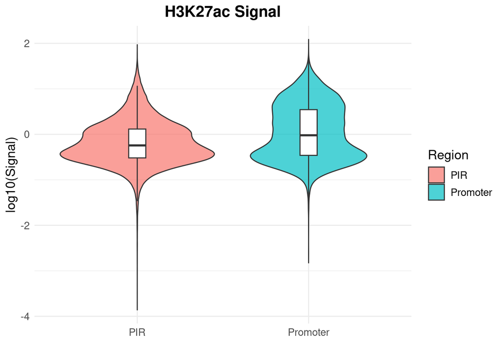

**Figure 1.** Violin plot of the log₁₀-transformed H3K27ac signal in CD14⁺ monocyte promoters and PIRs. The distribution of signal intensity is shown for each type of region: promoters (blue) and PIRs (red).

```r
library(ggplot2)
library(dplyr)
#Subir los archivos de señal de la histona para los promotores y PIR's
promoters = read.table("/home/yael/2025-2/Bioinformatica/Epigenomica/data/promoters_signal.tab", header = FALSE)
pirs = read.table("/home/yael/2025-2/Bioinformatica/Epigenomica/data/PIRs_signal.tab", header = FALSE)

#Asignar nombres a las columnas
colnames(promoters) <- colnames(pirs) <- c("ID", "size", "covered", "sum", "mean0", "mean1")

# Extraer la señal promedio (usaremos mean0)
signal_promoters <- promoters$mean0
signal_pirs <- pirs$mean0

# Combinar en un data frame para graficar
signal_data <- data.frame(
  Signal = c(signal_promoters, signal_pirs),
  Region = c(rep("Promoter", length(signal_promoters)), rep("PIR", length(signal_pirs)))
)


signal_data_filtered <- signal_data %>% filter(Signal > 0)
signal_data_filtered$LogSignal <- log10(signal_data_filtered$Signal)

ggplot(signal_data_filtered, aes(x = Region, y = LogSignal, fill = Region)) +
  geom_violin(trim = FALSE, alpha = 0.7) +
  geom_boxplot(width = 0.1, fill = "white", outlier.shape = NA) +
  labs(title = "H3K27ac Signal", y = "log10(Signal)", x = "") +
  theme_minimal()+
    theme(
    text = element_text(size = 13),
    plot.title = element_text(face = "bold", hjust = 0.5)
  )
```

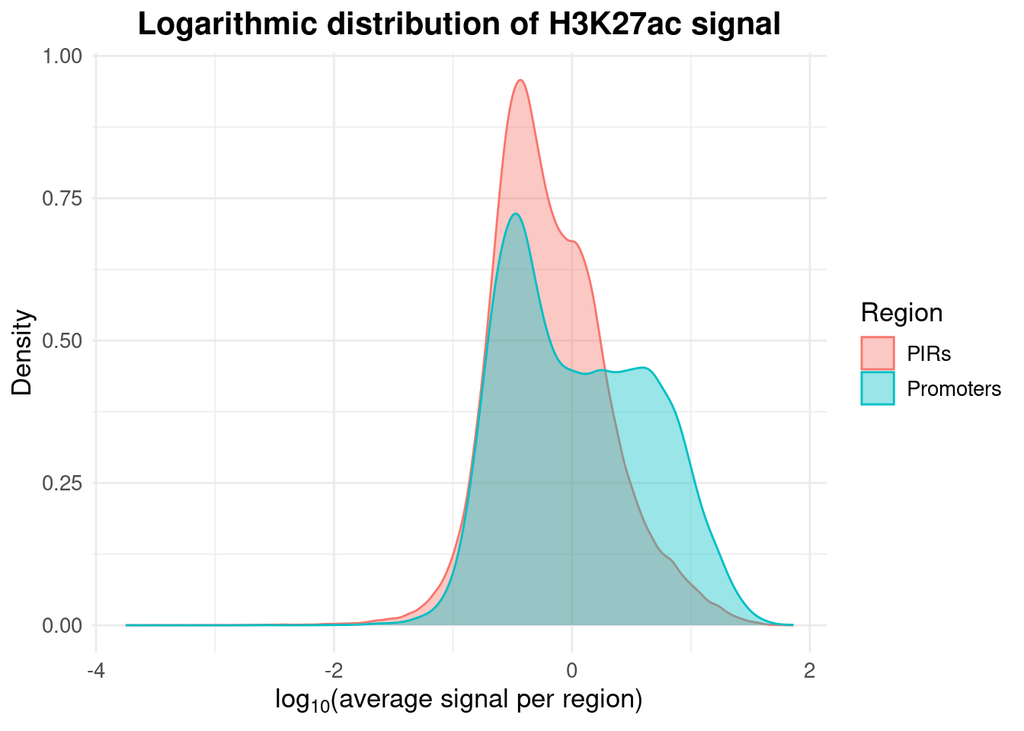

**Figure 2.** Density plot of the log₁₀-transformed H3K27ac signal in CD14⁺ monocyte promoters and PIRs. The plot shows the normalized distribution of signal intensity across both types of regulatory regions. Promoters are shown in cyan and PIRs in red.

```r
library(tidyverse)
# Añadir columna de tipo
promoters <- promoters %>% mutate(type = "Promoters")
pirs <- pirs %>% mutate(type = "PIRs")

# Unir ambos
all_data <- bind_rows(promoters, pirs)

# Quitar valores cero para evitar -Inf en log10
all_data_filtered <- all_data %>%
  filter(mean0 > 0) %>%
  mutate(log10_signal = log10(mean0))

# Graficar
ggplot(all_data_filtered, aes(x = log10_signal, fill = type, color = type)) +
  geom_density(alpha = 0.4) +
  labs(
    title = "Logarithmic distribution of H3K27ac signal",
    x = expression(log[10]*"(average signal per region)"),
    y = "Density",
    fill = "Region",
    color = "Region"
  ) +
  theme_minimal() +
  theme(
    text = element_text(size = 13),
    plot.title = element_text(face = "bold", hjust = 0.5)
  )
```

The density plot (Figure 2) reveals the global distribution of H3K27ac signal intensities on a logarithmic scale. The distribution for promoters is skewed toward higher values, indicating consistent enrichment of this active histone mark, in line with their role in transcription initiation. Promoters exhibit a shoulder at log₁₀(signal) > 0, suggesting a subset of highly acetylated regions.

In contrast, the PIR distribution is more narrowly centered and peaks at lower signal values, with most regions exhibiting modest H3K27ac levels. This supports the idea that, while some PIRs may be active enhancers marked by H3K27ac, the overall population is more heterogeneous in chromatin state and activity.

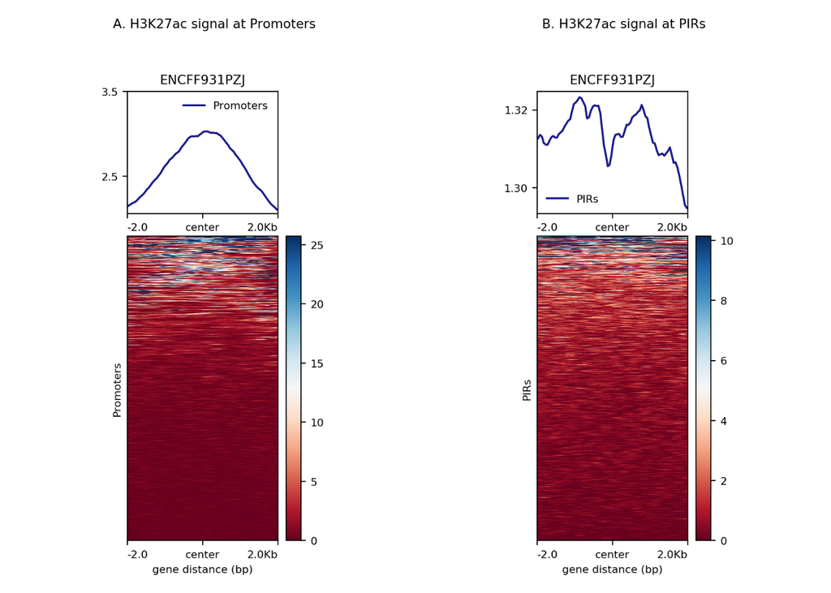

**Figure 3.** Heatmaps of raw H3K27ac signal enrichment in (A) promoters and (B) promoter-interacting regions (PIRs) from CD14⁺ monocytes. Each row represents an individual genomic region (±2 kb from the center), with signal intensity scaled from low (red) to high (blue). No z-score normalization.

**The raw signal heatmaps (Figure 3)** provide spatial information on H3K27ac enrichment around the centers of regulatory regions (±2 kb).

Overall, the raw heatmaps highlight the differential intensity and spatial coherence of H3K27ac enrichment between promoters and PIRs, reflecting their distinct regulatory architectures.

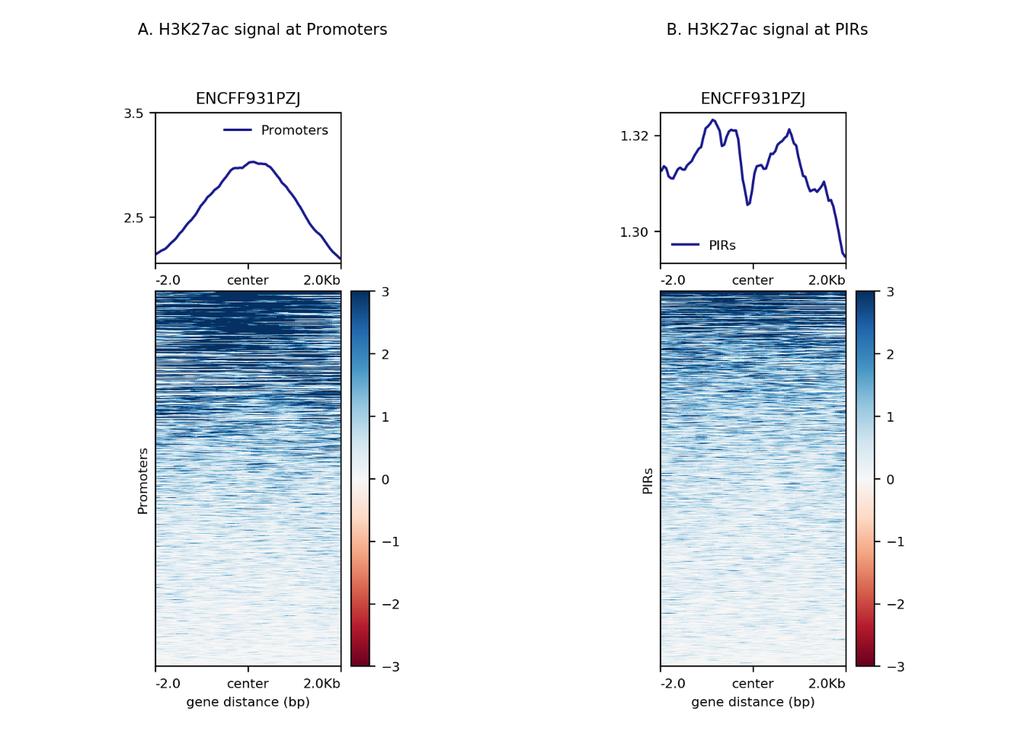

The z-score normalization emphasizes that while both promoters and PIRs can show H3K27ac enrichment, **promoters have a more focused and uniform activation profile**, whereas **PIRs display greater variability both in location and intensity of enrichment**.

Together, violin plots, density distributions, and heatmaps provide a consistent and comprehensive view of H3K27ac signal enrichment across promoters and PIRs. These complementary visualizations reveal both global trends and local variations, reinforcing the functional distinction between these regulatory regions. Overall, they offer a robust framework to interpret the epigenetic landscape shaping gene regulation in CD14+ monocytes.

**Statistical Test**

To assess whether the observed differences in H3K27ac signal between promoters and PIRs are statistically significant, we performed a **Wilcoxon rank-sum test** (non-parametric), given that the log-transformed signal values still showed asymmetric distributions.

```r
wilcox.test(signal_promoters, signal_pirs)
```

```
##
##  Wilcoxon rank sum test with continuity correction
##
## data:  signal_promoters and signal_pirs
## W = 2889434404, p-value < 2.2e-16
## alternative hypothesis: true location shift is not equal to 0
```

The test yielded a **p-value < 2.2e-16**, indicating a **highly significant difference** between the two distributions. This confirms that the enrichment of H3K27ac is systematically greater at promoter regions than at PIRs in monocytes.

**Descriptive Statistics**

Below are the summary statistics for the untransformed H3K27ac signal (`mean0`) in both types of regions:

```r
# Calcular estadísticas para cada tipo
stats_table <- all_data %>%
  group_by(type) %>%
  summarise(
    n_total = n(),
    mean_signal = mean(mean0),
    median_signal = median(mean0),
    sd_signal = sd(mean0),
    iqr_signal = IQR(mean0),
    max_signal = max(mean0),
    prop_above_0_5 = sum(mean0 > 0.5) / n()
  )

# Opcional: versión en formato tabla visual
library(knitr)
kable(stats_table, digits = 3, caption = "Descriptive statistics of signal H3K27ac")
```

Descriptive statistics of signal H3K27ac

| type | n_total | mean_signal | median_signal | sd_signal | iqr_signal | max_signal | prop_above_0_5 |
| --- | --- | --- | --- | --- | --- | --- | --- |
| PIRs | 232964 | 1.327 | 0.564 | 2.545 | 0.999 | 72.803 | 0.543 |
| Promoters | 20487 | 2.828 | 0.952 | 4.446 | 3.143 | 72.803 | 0.637 |

## Transcription factor motif enrichment in monocyte promoters

### Motif enrichment by observed frequency

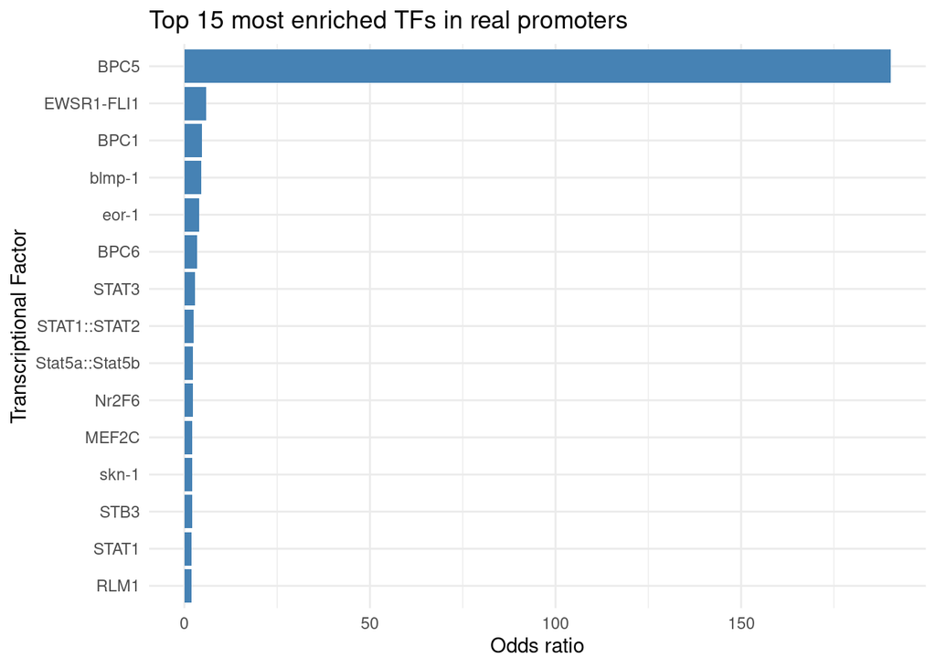

```r
library(ggplot2)

# Importa los archivos
fisher_all <- read.csv("/home/yael/2025-2/Bioinformatica/Epigenomica/data/promoters_fisher_results.csv")
fisher_sig <- read.csv("/home/yael/2025-2/Bioinformatica/Epigenomica/data/promoters_fisher_results_significant.csv")

top_tf <- fisher_sig[order(-fisher_sig$odds_ratio), ][1:15, ]

ggplot(top_tf, aes(x = reorder(ft_name, odds_ratio), y = odds_ratio)) +
  geom_col(fill = "steelblue") +
  coord_flip() +
  labs(
    title = "Top 15 most enriched TFs in real promoters",
    x = "Transcriptional Factor",
    y = "Odds ratio"
  ) +
  theme_minimal()
```

This set highlights a strong enrichment of immune-related and differentiation-associated TFs in monocyte promoters, especially those involved in **JAK-STAT signaling**, **hematopoietic development**, and **stress-responsive pathways**.

Some TFs, such as BPC family members, blmp-1, or eor-1, originate from non-human organisms in the JASPAR database. Their enrichment in human promoter sequences likely reflects motif similarity to human zinc finger or chromatin regulators rather than direct functional roles.

### Motif enrichment based on statistical significance (FDR)

We show the TF motifs with the **lowest FDR values**, capturing the most robust enrichments independent of absolute motif counts. (Figure 6)

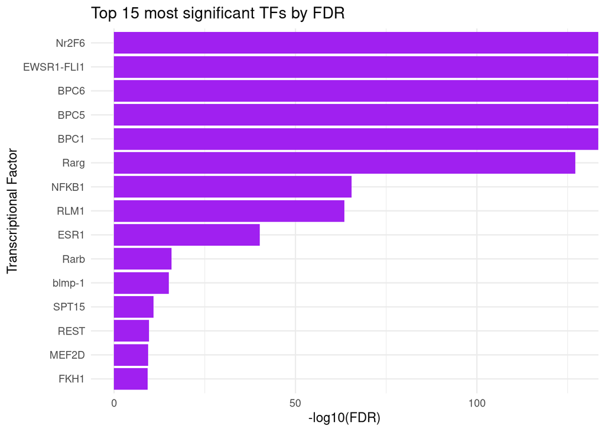

**Figure 6.** Top 15 transcription factor motifs with most statistically significant enrichment (lowest FDR values) in CD14⁺ monocyte promoters. Bars represent –log₁₀(FDR), highlighting motifs that are most significantly overrepresented relative to random sequences.

```r
top_fdr <- fisher_sig[order(fisher_sig$fdr), ][1:15, ]
top_fdr$log10_fdr <- -log10(top_fdr$fdr)

ggplot(top_fdr, aes(x = reorder(ft_name, log10_fdr), y = log10_fdr)) +
  geom_col(fill = "purple") +
  coord_flip() +
  labs(
    title = "Top 15 most significant TFs by FDR",
    x = "Transcriptional Factor",
    y = "-log10(FDR)"
  ) +
  theme_minimal()
```

- **Nr2F6**, a nuclear receptor linked to **immune tolerance and T-cell suppression**, ranks at the top, suggesting **direct regulatory roles in monocyte gene silencing or immune modulation**.
- Consistent enrichment of **BPC1, BPC5, BPC6**, again showing cross-species similarity and possible relevance of **C2H2-type zinc finger motifs**.
- **Rarg** and **Rarb**, retinoic acid receptors, reflect **developmental signaling pathways** relevant to monocyte maturation.
- **NFKB1**, a key TF in **inflammation and immune activation**, shows significant enrichment, validating the functional relevance of the method.
- **REST**, a repressor associated with **silencing of neuronal genes in non-neuronal tissues**, appears enriched, potentially marking **repression of lineage-inappropriate programs**.
- **SPT15** and **FKH1**, again from yeast, likely represent homologous motifs for **TATA-binding protein (TBP)** and **FOXO family** TFs, both important in transcriptional regulation under stress or metabolic states.
- **MEF2D**, a paralog of MEF2C, further reinforces the importance of **myeloid differentiation TFs** in promoter architecture.

Taken together, the statistical enrichment points to **functionally diverse yet coherent sets of TFs** acting in concert to orchestrate monocyte-specific transcriptional programs.

### Motif enrichment landscape: Volcano plot

To integrate both the magnitude and significance of motif enrichment, we generated a volcano plot summarizing log₂(odds ratio) versus –log₁₀(FDR) for all TF motifs (Figure 7). This visualization highlights motifs that are both strongly enriched and statistically significant. Motifs falling in the upper-right quadrant (log₂OR > 1 and FDR < 0.05) represent the most robust candidates for functional relevance in monocyte promoter regulation.

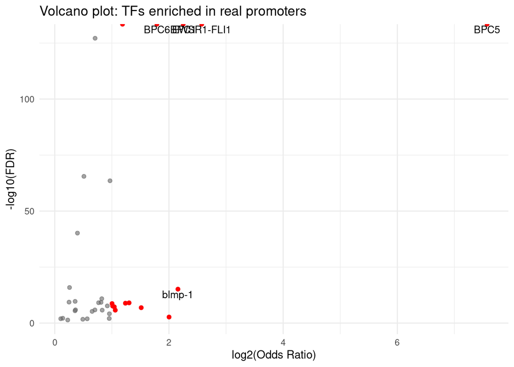

**Figure. 7** Volcano plot of TFs motif enrichment in CD14⁺ monocyte promoters. Shown is log2(odds ratio) versus -log10(FDR) for each motif identified by RSAT compared with permuted sequences. Significantly enriched motifs (FDR < 0.05 and log2OR > 1) are highlighted in red. More robust motifs (FDR < 1e-10 and log2OR > 1.5) are labeled.

```r
fisher_sig$log2_OR <- log2(fisher_sig$odds_ratio)
fisher_sig$neg_log10_fdr <- -log10(fisher_sig$fdr)


ggplot(fisher_sig, aes(x = log2_OR, y = neg_log10_fdr)) +
  geom_point(alpha = 0.6, color = "gray40") +
  geom_point(data = subset(fisher_sig, fdr < 0.05 & log2_OR > 1),
             aes(x = log2_OR, y = neg_log10_fdr), color = "red") +
  geom_text(data = subset(fisher_sig, fdr < 1e-10 & log2_OR > 1.5),
            aes(label = ft_name), vjust = 1.2, size = 3.5) +
  labs(
    title = "Volcano plot: TFs enriched in real promoters",
    x = "log2(Odds Ratio)",
    y = "-log10(FDR)"
  ) +
  theme_minimal()
```

The volcano plot further reinforces this interpretation, showcasing a cluster of robustly enriched motifs with high effect sizes and statistical confidence. Notably, the presence of conserved or homologous motifs from non-human systems (e.g., BPC, SPT15, FKH1) points to deeper structural constraints in promoter sequence evolution or to shared functional logic across species. Overall, these findings support the hypothesis that monocyte promoters harbor a distinct repertoire of regulatory elements finely tuned for immune identity and responsiveness.

### Questions

1. **Why does the JASPAR non-redundant collection should be used?**

   The non-abundant JASPAR collection has the advantage of identifying transcription factors (TFs) in promoters or enhancers due to its precision in including TFs specific to these regulatory regions, which reduces noise and increases the biological relevance of the results. This focus also facilitates the interpretation of the data by limiting the number of TFs to be analyzed, which allows the most relevant TFs to be identified more clearly for the study context.
2. **Why does usign permuted sequences serve as a control?**

   It is useful for noise reduction, because it provides a reference to evaluate the results obtained with the original sequences. Comparing the results obtained with the original sequences versus the permuted ones allows us to distinguish between real signal and background noise. If significant patterns are observed in the original sequences that are not present in the permuted ones, it is more likely that these patterns are biologically relevant and not simply the result of chance or methodological biases.

# Conclusion

Our analysis of H3K27ac enrichment in CD14+ monocytes demonstrates that this epigenetic mark is significantly more enriched in promoters than in distal interacting regions (PIRs), both in terms of raw signal and its overall distribution. This result is consistent with the well-established role of H3K27ac as a marker of transcriptional activity, particularly in active promoter regions.

Complementary transcription factor motif analysis, performed only on promoter sequences, identified a significantly enriched set of binding sites relative to permuted sequences. This indicates that the active promoters in monocytes are not only enriched in H3K27ac, but also present a distinct repertoire of regulatory motifs that could mediate transcriptional specificity in this cell type. This convergence between epigenetic modification and recognition signals by transcriptional factors reinforces the biological functionality of these regions as centers of regulatory integration.

Taken together, these results support the choice of H3K27ac as an epigenetic marker to study the functionality of promoter regions and allow us to discriminate between regions with different regulatory potential in the context of CD14+ monocytes.

# References

## Articles

- Barozzi I, Simonatto M, Bonifacio S, Yang L, Rohs R, Ghisletti S, Natoli G. Coregulation of transcription factor binding and nucleosome occupancy through DNA features of mammalian enhancers. Mol Cell. 2014 Jun 5;54(5):844-857. doi: 10.1016/j.molcel.2014.04.006. Epub 2014 May 8. PMID: 24813947; PMCID: PMC4048654.
- Gosselin D, Link VM, Romanoski CE, Fonseca GJ, Eichenfield DZ, Spann NJ, Stender JD, Chun HB, Garner H, Geissmann F, Glass CK. Environment drives selection and function of enhancers controlling tissue-specific macrophage identities. Cell. 2014 Dec 4;159(6):1327-40. doi: 10.1016/j.cell.2014.11.023. PMID: 25480297; PMCID: PMC4364385.
- Javierre BM, Burren OS, Wilder SP, Kreuzhuber R, Hill SM, Sewitz S, Cairns J, Wingett SW, Várnai C, Thiecke MJ, Burden F, Farrow S, Cutler AJ, Rehnström K, Downes K, Grassi L, Kostadima M, Freire-Pritchett P, Wang F; BLUEPRINT Consortium; Stunnenberg HG, Todd JA, Zerbino DR, Stegle O, Ouwehand WH, Frontini M, Wallace C, Spivakov M, Fraser P. Lineage-Specific Genome Architecture Links Enhancers and Non-coding Disease Variants to Target Gene Promoters. Cell. 2016 Nov 17;167(5):1369-1384.e19. doi: 10.1016/j.cell.2016.09.037. PMID: 27863249; PMCID: PMC5123897.
- Jolma A, Yan J, Whitington T, Toivonen J, Nitta KR, Rastas P, Morgunova E, Enge M, Taipale M, Wei G, Palin K, Vaquerizas JM, Vincentelli R, Luscombe NM, Hughes TR, Lemaire P, Ukkonen E, Kivioja T, Taipale J. DNA-binding specificities of human transcription factors. Cell. 2013 Jan 17;152(1-2):327-39. doi: 10.1016/j.cell.2012.12.009. PMID: 23332764.
- Turatsinze, J.-V., Thomas-Chollier, M., Defrance, M., & van Helden, J. (2008). Using RSAT to scan genome sequences for transcription factor binding sites and cis-regulatory modules. Nature Protocols, 3(10), 1578–1588. https://doi.org/10.1038/nprot.2008.97

## Software Used

- **Data Processing & File Management**
  - `awk` 4.0.2 – Text processing for BED files
  - `wc` (GNU coreutils) 8.22 – Line counting
  - `wget` 1.4 – File downloads from ENCODE
  - `zcat` (gzip) 1.5 – Decompression of `.gz` files
- **Genomic Tools**
  - `BEDTools` 2.27.1 – Sequence extraction (`getfasta`)
  - `UCSC tools`:
    - `bigWigInfo` – Chromosome size extraction
    - `bigWigAverageOverBed` – Signal quantification
- **Epigenomic Analysis**
  - `DeepTools` 2.5.3:
    - `computeMatrix` – Signal aggregation
    - `plotHeatmap` – Visualization of H3K27ac patterns
- **Motif Analysis**
  - `RSAT` 8sep2021:
    - `create-background-model` – Markov chain modeling
    - `matrix-scan` – TF motif scanning (JASPAR 2022)
- **Statistical Analysis & Scripting**
  - `R` 4.0.2 & 4.4.2 – Fisher’s exact tests, data wrangling
    - Key packages: `data.table`, `Biostrings` (for sequence shuffling)
- **Visualization & Utilities**
  - `ImageMagick` (`convert`) – Heatmap concatenation (optional)

## GitHub Reference

All scripts are available in the [Epigenomics repository](https://github.com/YaelHernG/Epigenomics/tree/main/Scripts)